# Activity manner prediction

Kirill Lebedev

# Summary

The goal of this research is to explore different machine learning models that could be used to predict weight lifting training quality based on data collected from wearable devices. Initial dataset is available from http://groupware.les.inf.puc-rio.br/har. You can also find a description of dataset by that link.

# Prerequisites

# Explaratory data analysis

First lets check what data do we have to train model:

```r
str(training)
```

```
## 'data.frame':    19622 obs. of  160 variables:
##  $ X                       : int  1 2 3 4 5 6 7 8 9 10 ...
##  $ user_name               : chr  "carlitos" "carlitos" "carlitos" "carlitos" ...
##  $ raw_timestamp_part_1    : int  1323084231 1323084231 1323084231 1323084232 1323084232 1323084232 1323084232 1323084232 1323084232 1323084232 ...
##  $ raw_timestamp_part_2    : int  788290 808298 820366 120339 196328 304277 368296 440390 484323 484434 ...
##  $ cvtd_timestamp          : chr  "05/12/2011 11:23" "05/12/2011 11:23" "05/12/2011 11:23" "05/12/2011 11:23" ...
##  $ new_window              : chr  "no" "no" "no" "no" ...
##  $ num_window              : int  11 11 11 12 12 12 12 12 12 12 ...
##  $ roll_belt               : num  1.41 1.41 1.42 1.48 1.48 1.45 1.42 1.42 1.43 1.45 ...
##  $ pitch_belt              : num  8.07 8.07 8.07 8.05 8.07 8.06 8.09 8.13 8.16 8.17 ...
##  $ yaw_belt                : num  -94.4 -94.4 -94.4 -94.4 -94.4 -94.4 -94.4 -94.4 -94.4 -94.4 ...
##  $ total_accel_belt        : int  3 3 3 3 3 3 3 3 3 3 ...
##  $ kurtosis_roll_belt      : chr  "" "" "" "" ...
##  $ kurtosis_picth_belt     : chr  "" "" "" "" ...
##  $ kurtosis_yaw_belt       : chr  "" "" "" "" ...
```

[output cut: 86 more lines]

Training dataset consists 160 columns and 19622 columns. Let’s check activity types distribution first:

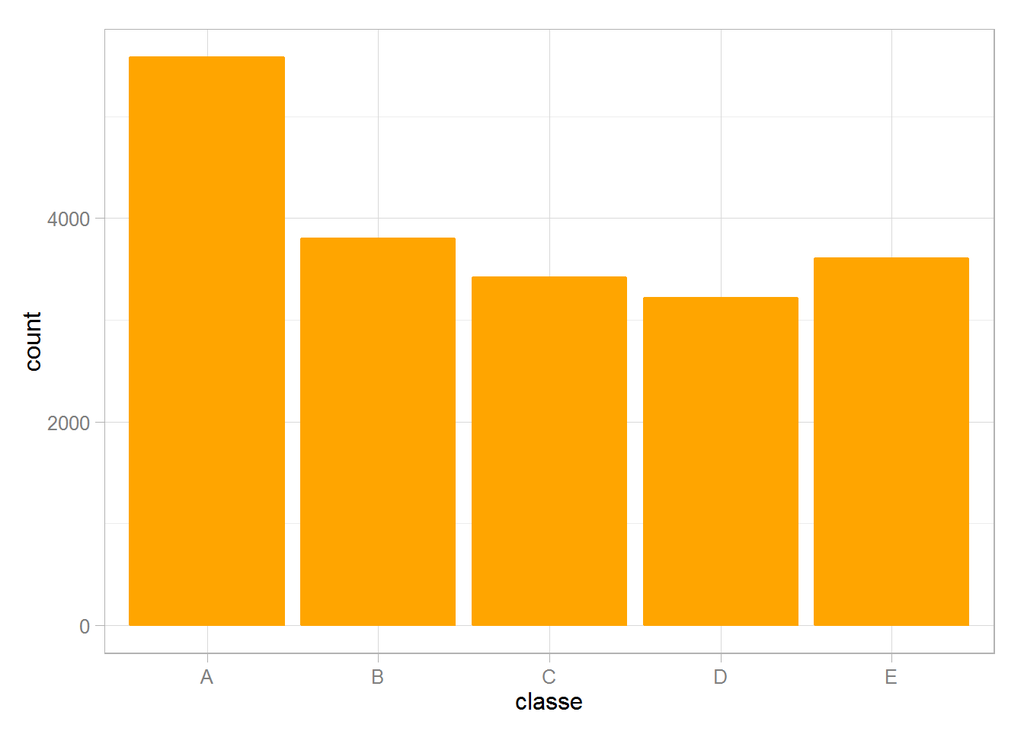

```r
qplot(classe, data=training, fill=I("orange"), color=I("orange")) + theme_light()
```

```r
colstotal <- colnames(training)[grep("^total", colnames(training))]
cols <- colnames(training)[grep("^[a-z]*_[a-z]*$", colnames(training))][5:16]
```

Now lets plot total predictors correlation plots:

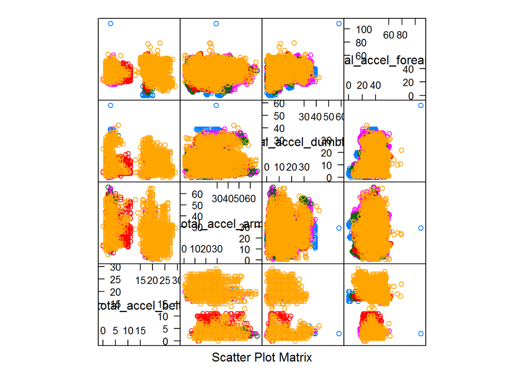

```r
featurePlot(training[,colstotal], training$classe, plot="pairs")
```

Lets also plot raw activities predictors correlation plots:

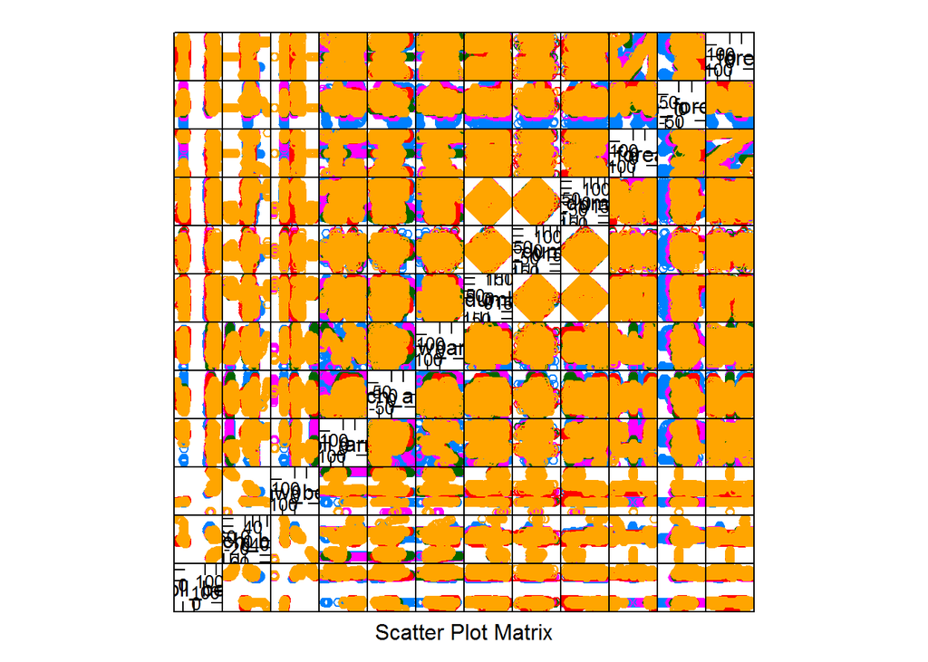

```r
featurePlot(training[,cols], training$classe, plot="pairs")
```

As we see from diagrams there is now significant correlation between predictors.